# R Notebook

*1. Importing gene expression quantifications from ENCODE* Load gene expression data from ENCODE and integrate with GENCODE data, select the data corresponding to a female donnor of 51 years old from tibial nerve.

```r
# Get 2 cols from data and the genes that start with ENSG
nerve.gene <- nerve.gene[grep(pattern = "ENSG",x = nerve.gene$gene_id),c("gene_id","expected_count")]
```

[output not shown]

Explore gene expression distribution in tibial nerve.

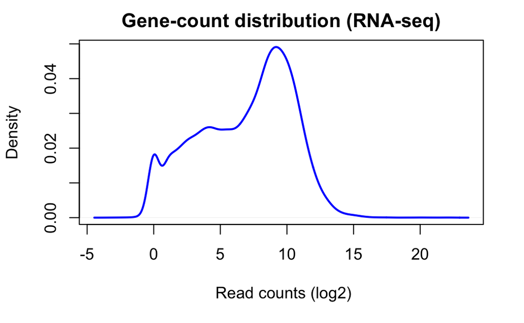

```r
# Explore the distribution for the gene expression values
plot(density(log2(nerve.gene$count)),
     main="Gene-count distribution (RNA-seq)",
     col="blue",
     lwd=2,
     xlab=" Read counts (log2)")
```

*2. Importing H3K4me3 ChIP-seq data (peak file) from ENCODE* Explore the data from a ChIP-seq experiment for H3K4me3, select the data corresponding to a female donnor of 51 years old from tibial nerve.

```r
#Check the structure of the data form ENCODE for H3K4me3
head(nerve.peaks)
```

```
GRanges object with 6 ranges and 6 metadata columns:
      seqnames              ranges strand |        name     score signalValue    pValue    qValue
         <Rle>           <IRanges>  <Rle> | <character> <numeric>   <numeric> <numeric> <numeric>
  [1]    chr10 100008375-100010660      * |   Peak_7408       347     22.0936  103.8384  100.7032
  [2]    chr10 100184850-100187011      * |   Peak_4761       441     22.6900  132.2566  128.7471
  [3]    chr10 100228671-100230207      * |   Peak_3079       504     24.9944  151.2839  147.4678
  [4]    chr10 100266796-100268319      * |   Peak_7930       323     16.1727   96.7072   93.6507
  [5]    chr10 100285646-100287072      * |   Peak_1675       568     25.5569  170.5941  166.4046
  [6]    chr10 100346196-100348355      * |   Peak_6449       382     24.2164  114.5314  111.2676
           peak
      <integer>
  [1]      1166
  [2]       970
  [3]       773
  [4]       624
  [5]       857
  [6]      1123
  -------
  seqinfo: 27 sequences from an unspecified genome; no seqlengths
```

Check peak signal distribution

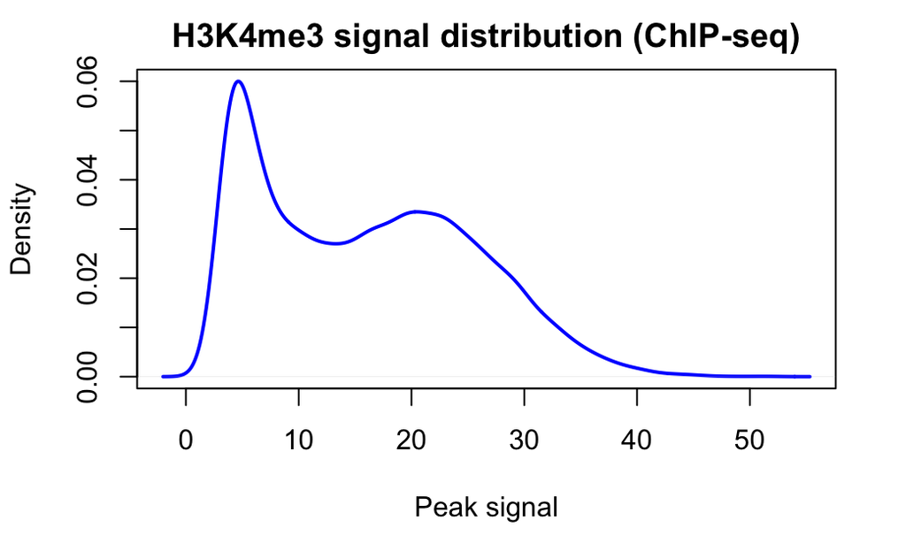

```r
# Explore the distribution for the gene expression values
plot(density(nerve.peaks$signalValue),
     main="H3K4me3 signal distribution (ChIP-seq)",
     col="blue",
     lwd=2,
     xlab="Peak signal")
```

*3. Load GENCODE for GRCh38 as gene annotation file*

```r
nrow(gencode)
```

```
[1] 58721
```

Scatter plot for Chromosome 1

```r
plot(nerve.peaks.1@ranges@start/1E6,
     nerve.peaks.1$signalValue,
     col="blue",
     cex=0.1,
     #xlim=c(10,30),
     ylim=c(0,50),
     xlab="Genome positoin (Mb)",
     ylab="H3K4me3")

# We manually adjust the genes in an upper position compared to H3K4me3
segments(x0 = nerve.gene.pos.1$start/1E6,
         y0 = log2(nerve.gene.pos.1$count)+30,
         x1 = nerve.gene.pos.1$end/1E6,
         y1 = log2(nerve.gene.pos.1$count)+30,
         col = "red",
         lwd=1.5)
```

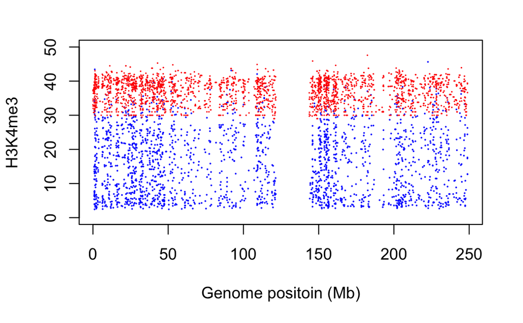

```r
abline(h=mean(log2(nerve.gene.pos.1$count)+30), lwd=0.7)
```

*5. Analysing H3K4me3 signal at gene TSS* Explore H3K4me3 signal at gene promoters (TSS, 3Kb upstream and 2Kb downstream).

```r
subjectHits(peak.tissue.overlap)
```

[output not shown]

[output cut: 53 more lines]

*6. Relationship between gene expression and histone marks*

```r
summary(nerve.gene$count)
```

```
   Min. 1st Qu.  Median    Mean 3rd Qu.    Max.
      0       0       0     559      36 5318209
```

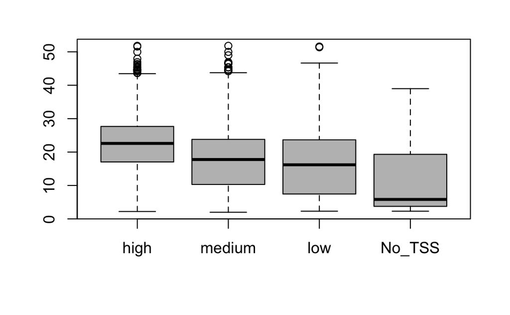

```r
boxplot(subset(gene.peak.nerve.overlap.full, Q_count > 559)$S_signalValue,
        subset(gene.peak.nerve.overlap.full, Q_count > 0 & Q_count < 559)$S_signalValue,
        subset(gene.peak.nerve.overlap.full, Q_count == 0)$S_signalValue,
        subset(nerve.peaks, !peak%in%gene.peak.nerve.overlap.full$S_peak)$signalValue,
        names=c("high","medium","low","No_TSS"), col="grey")
```

```r
#Check the structure of the data form ENCODE for H3K27me3
head(nerve.peaks)
```

```
GRanges object with 6 ranges and 6 metadata columns:
                    seqnames              ranges strand |
                       <Rle>           <IRanges>  <Rle> |
  [1] chr22_KI270733v1_ran..       149721-149834      * |
  [2]                  chr10 133335577-133335840      * |
  [3]                  chr19   55082552-55083066      * |
  [4]                   chr5   73451335-73451452      * |
  [5]                   chr2 172097613-172097816      * |
  [6]                   chr7   23473377-23473890      * |
             name     score signalValue    pValue    qValue
      <character> <numeric>   <numeric> <numeric> <numeric>
  [1]      Peak_1      1000     2.39647  13.42365   5.27505
  [2]      Peak_2       652     5.33891   9.41565   1.82226
  [3]      Peak_3       652     5.33891   9.41565   1.82226
  [4]      Peak_4       635     4.82733   9.25272   1.73942
  [5]      Peak_5       617     5.14373   9.07350   1.63170
  [6]      Peak_6       617     4.73268   9.06829   1.63170
           peak
      <integer>
  [1]        42
  [2]       177
  [3]       100
  [4]        85
  [5]        65
  [6]       229
  -------
  seqinfo: 42 sequences from an unspecified genome; no seqlengths
```

7_Check peak signal distribution

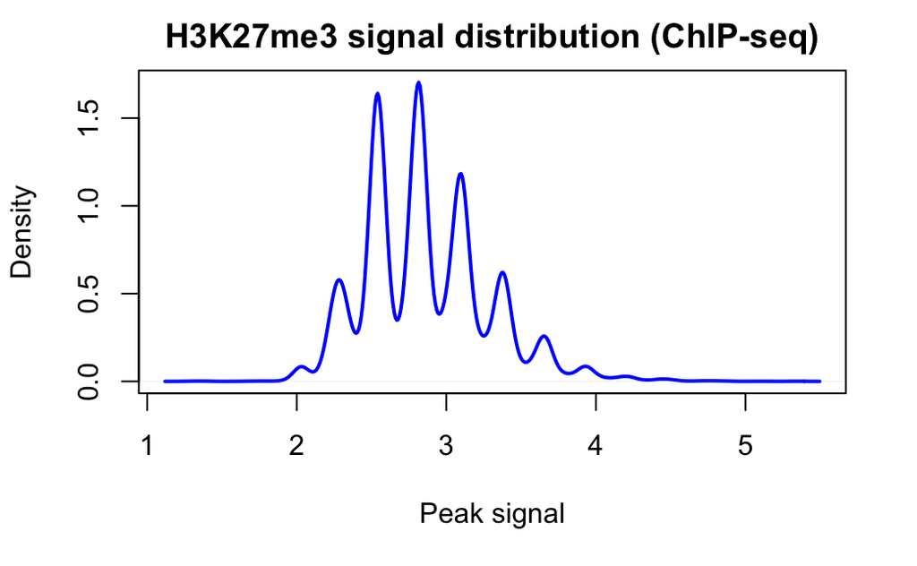

```r
# Explore the distribution for the gene expression values
plot(density(nerve.peaks$signalValue),
     main="H3K27me3 signal distribution (ChIP-seq)",
     col="blue",
     lwd=2,
     xlab="Peak signal")
```

7_3. Load GENCODE for GRCh38 as gene annotation file

```r
gencode <- read.table("https://www.dropbox.com/s/le9vs2n51lsxlw1/gencode_GRCh38.txt?dl=1",
                      header=TRUE,
                      stringsAsFactors = FALSE)

# Annotate nerve.gene with gencode data
nerve.gene.pos <- merge(gencode, nerve.gene, by="gene_id", all.x=TRUE)
nrow(gencode)
```

```
[1] 58721
```

```r
# We combine gene expression data and gencode to get gene genomic coordinates.
nerve.gene.pos <- subset(nerve.gene.pos, !is.na(start))

# We select a chromosome for the plot
nerve.peaks.1 <- subset(nerve.peaks, seqnames=="chr1")
nerve.gene.pos.1 <- subset(nerve.gene.pos, chromosome=="chr1")
```

7_Scatter plot for Chromosome 1

```r
plot(nerve.peaks.1@ranges@start/1E6,
     nerve.peaks.1$signalValue,
     col="blue",
     cex=0.1,
     #xlim=c(10,30),
     ylim=c(0,50),
     xlab="Genome positoin (Mb)",
     ylab="H3K27me3")

# We manually adjust the genes in an upper position compared to H3K4me3
segments(x0 = nerve.gene.pos.1$start/1E6,
         y0 = log2(nerve.gene.pos.1$count)+30,
         x1 = nerve.gene.pos.1$end/1E6,
         y1 = log2(nerve.gene.pos.1$count)+30,
         col = "red",
         lwd=1.5)
```

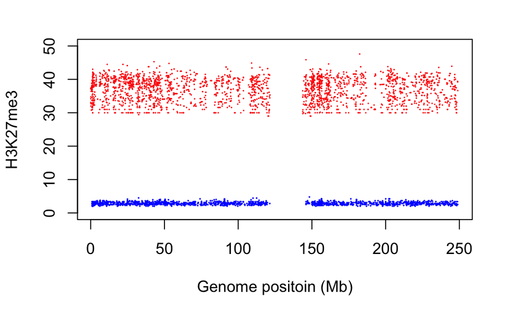

```r
abline(h=mean(log2(nerve.gene.pos.1$count)+30), lwd=0.7)
```

7_5. Analysing H3K27me3 signal at gene TSS Explore H3K27me3 signal at gene promoters (TSS, 3Kb upstream and 2Kb downstream).

```r
library(GenomicRanges)

# Annotation data from gencode to GRanges format
# Load genomic coordinates of genes as genomic range object
gr.gene <- GRanges(seqnames = nerve.gene.pos$chromosome,
                          ranges = IRanges(start = nerve.gene.pos$start, end = nerve.gene.pos$end),
                          strand = nerve.gene.pos$strand,
                          geneID = nerve.gene.pos$gene_name,
                          type=nerve.gene.pos$type,
                          count=nerve.gene.pos$count)
# Get promoters
gr.tss <- promoters(x = gr.gene, upstream = 3000, downstream = 2000)

# H3K4me3 peaks were imported directly into a genomic range object

# Find the overlap between the promoter and the peak
peak.tissue.overlap <- findOverlaps(query = gr.tss, subject = nerve.peaks)
# Get the index of elements in the query that overlaps with an element in the subject
queryHits(peak.tissue.overlap)
subjectHits(peak.tissue.overlap)

# We make two diferent data frames with the same number of rows that will be combined into 1 data frame.
genes.overlaps <- as.data.frame(gr.tss[queryHits(peak.tissue.overlap)])
peak.overlaps <- as.data.frame(nerve.peaks[subjectHits(peak.tissue.overlap)])

## Change the names of the columns add a prefix Q (for query) and S (for subjet).
colnames(genes.overlaps) <- paste0("Q_",colnames(genes.overlaps))
colnames(peak.overlaps) <- paste0("S_",colnames(peak.overlaps))

# Combine the table of overlapping genes with the table of their overlapping genetic variants
gene.peak.nerve.overlap.full <- cbind(genes.overlaps, peak.overlaps)
```

7_6. Relationship between gene expression and histone marks

```r
summary(nerve.gene$count)
```

```
   Min. 1st Qu.  Median    Mean 3rd Qu.    Max.
      0       0       0     559      36 5318209
```

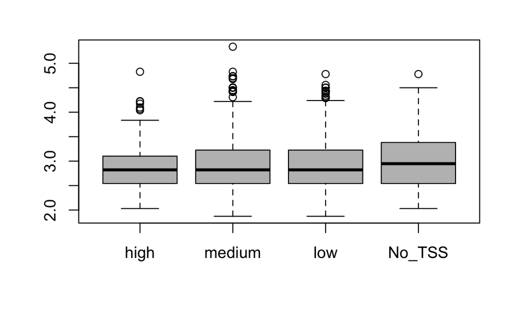

```r
# High > 599
# Medium 0-599
# Low 0
# No TSS not in dataset
boxplot(subset(gene.peak.nerve.overlap.full, Q_count > 559)$S_signalValue,
        subset(gene.peak.nerve.overlap.full, Q_count > 0 & Q_count < 559)$S_signalValue,
        subset(gene.peak.nerve.overlap.full, Q_count == 0)$S_signalValue,
        subset(nerve.peaks, !peak%in%gene.peak.nerve.overlap.full$S_peak)$signalValue,
        names=c("high","medium","low","No_TSS"), col="grey")
```

*8. Get Transcription Factor (TF) Binding Sites from ChIP-seq experiments* Complete the next steps to load the peakset for any Transcription Factor (TF) from ReMap Database. These steps will be helpful to complete the homeworks, a TF has been assigned to you check it here.

- First, go to ReMap 2022 > Downloads > Search for the required TF.
- Search your TF and copy the link for merged peaks and Human Genome Assembly hg38.
- Go to the UNIX terminal that is available in RStudio cloud and use the following UNIX commands. Note: do not run them into the R console, do it in RStudio cloud terminal window or do a normal download and upload the file into RStudio cloud.

```r
# This command download the file merged peak file of your TF
#wget https://remap.univ-amu.fr/storage/remap2022/hg38/MACS2/TF/SP1/remap2022_SP1_nr_macs2_hg38_v1_0.bed.gz

# This command decompress the ".bed.gz" file
#gzip -d remap2022_SP1_nr_macs2_hg38_v1_0.bed.gz
```

Back to RStudio cloud console and read the bed file for SP1 using the following R commands:

```r
sp1.peaks <- read.table(file = "remap2022_SP1_nr_macs2_hg38_v1_0.bed", sep="\t")
sp1.peaks <- sp1.peaks[,c("V1","V2","V3","V5")]
sp1.peaks$peakID <- paste0("peakID_", 1:nrow(sp1.peaks))
colnames(sp1.peaks) <- c("chromosome","start","end","signal","peakID")
sp1.peaks$strand <- rep(x = "*", times=nrow(sp1.peaks))
```